# Preliminary workflow for supervised machine learning regression & classification tasks

**Date:** March 21, 2023

Prof. Chiu and I are evaluating the performances of supervised ML models at predicting toxicity outcomes of chemicals (N = ~1,000), for both a continuous target variable and several binary targets (positive or negative for different organ systems). We are thinking of trying different estimators, short-listing a few top-performing models, and then perhaps building an ensemble of top-performers for the final models.

I had a first pass at adapting the general workflow Prof. Wright recommended over email exchanges, as shown below. I would appreciate any feedback on this implementation. In addition, I have a some follow-up questions toward the end of this notebook.

```python
import pandas as pd
import numpy as np
from os import path
from sklearn.model_selection import train_test_split
from sklearn.ensemble import RandomForestRegressor
from sklearn.inspection import permutation_importance
import matplotlib.pyplot as plt
import parse, plot
# Enable modules to be imported from the parent directory.
import sys
sys.path.append('..')
from common.input_output import read_csv_files
from common.features import with_common_index
```

## Load the target variables

```python
effect_type = 'non-reproductive/developmental effects'
exposure_route = 'oral'
target_variable = 'POD [mg/kg-d]'

target_continuous = (
    pd.read_csv(
        path.join('Input', 'log10-points-of-departure.csv'),
        index_col=0)
    [effect_type]
    .dropna())
```

```python
features_dir = 'Features'

file_for_features = {
    'properties': 'physical-chemical-properties.csv',
    'descriptors': 'molecular-descriptors.csv'}

index_col = 'DTXSID'

# NOTE: inner join preserves dtype if any NaN.
features = read_csv_files(
    features_dir,
    file_for_features.values(),
    index_col=index_col)
features = pd.concat(
    features, axis=1, join='inner')
```

```python
target_continuous, features = with_common_index([target_continuous, features])
```

### Continuous target

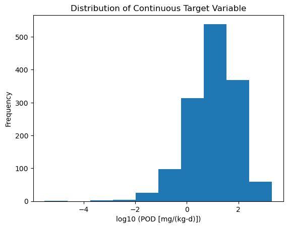

```python
fig, ax = plt.subplots()
target_continuous.plot.hist(ax=ax)
ax.set_title('Distribution of Continuous Target Variable')
ax.set_xlabel('log10 (POD [mg/(kg-d)])')
```

### Binary targets

Unbalanced classes for many of these organ systems. Considering using a stratified sampling strategy to preserve class proportions, while building N independent binary classifiers, one for each organ system.

```python
targets_binary = pd.read_csv(
    path.join('..', 'endpoint_classification', 'true-outcomes-1.csv'),
    index_col='chemical_id')

targets_binary
```

| chemical_id | cardiovascular | dermal | endocrine | enzyme | gastrointestinal | general | hematological | hepatic | immunological | musculoskeletal | neurological | ocular | other | renal | reproductive | respiratory | unknown |
| --- | --- | --- | --- | --- | --- | --- | --- | --- | --- | --- | --- | --- | --- | --- | --- | --- | --- |
| 57908 | 0.0 | 0.0 | 1.0 | NaN | 0.0 | 1.0 | 0.0 | 1.0 | 1.0 | 0.0 | 0.0 | NaN | NaN | 1.0 | 1.0 | 0.0 | NaN |
| 57912 | NaN | NaN | NaN | NaN | 1.0 | 1.0 | NaN | NaN | NaN | NaN | NaN | 1.0 | NaN | NaN | 1.0 | NaN | NaN |
| 57914 | NaN | NaN | 1.0 | NaN | NaN | 1.0 | NaN | NaN | NaN | NaN | NaN | NaN | NaN | NaN | NaN | NaN | NaN |
| 57915 | NaN | 0.0 | NaN | NaN | NaN | 1.0 | NaN | NaN | NaN | NaN | NaN | NaN | NaN | NaN | 0.0 | NaN | NaN |
| 57916 | NaN | 1.0 | NaN | NaN | NaN | 1.0 | 1.0 | NaN | NaN | NaN | NaN | NaN | NaN | 1.0 | NaN | NaN | NaN |
| ... | ... | ... | ... | ... | ... | ... | ... | ... | ... | ... | ... | ... | ... | ... | ... | ... | ... |
| 59037 | NaN | NaN | 0.0 | NaN | NaN | 1.0 | NaN | 0.0 | 0.0 | NaN | 0.0 | NaN | NaN | 0.0 | 0.0 | NaN | NaN |
| 59041 | NaN | NaN | 1.0 | NaN | NaN | 1.0 | NaN | NaN | NaN | NaN | NaN | NaN | NaN | NaN | NaN | NaN | NaN |
| 59046 | NaN | NaN | NaN | NaN | 1.0 | 1.0 | NaN | NaN | NaN | NaN | NaN | NaN | NaN | 1.0 | 1.0 | 1.0 | NaN |
| 59049 | 0.0 | NaN | 0.0 | NaN | NaN | 1.0 | NaN | 1.0 | 1.0 | NaN | NaN | NaN | NaN | 1.0 | 1.0 | 0.0 | NaN |
| 59050 | NaN | NaN | NaN | NaN | NaN | 1.0 | NaN | 1.0 | 1.0 | NaN | NaN | NaN | NaN | 1.0 | NaN | NaN | NaN |

741 rows × 17 columns

## Load the features

There are hundreds of candidate features describing the chemicals. We do not know a priori which features are important, and hence a feature importance/selection procedure would be useful. In addition, some of these features may benefit from preprocessing depending on the type of estimator.

```python
features
```

| DTXSID | Boiling Point | LogKow: Octanol-Water | Melting Point | Vapor Pressure | Water Solubility | pKa Acidic Apparent | pKa Basic Apparent | Henry's Law | LogKoa: Octanol-Air | Density | ... | fr_sulfide | fr_sulfonamd | fr_sulfone | fr_term_acetylene | fr_tetrazole | fr_thiazole | fr_thiocyan | fr_thiophene | fr_unbrch_alkane | fr_urea |
| --- | --- | --- | --- | --- | --- | --- | --- | --- | --- | --- | --- | --- | --- | --- | --- | --- | --- | --- | --- | --- | --- |
| DTXSID001006300 | 403.8065 | 2.855 | 157.4210 | 1.085070e-07 | 1.910402e+00 | NaN | NaN | 3.260260e-10 | 8.19567 | 0.9780 | ... | 0 | 0 | 0 | 0 | 0 | 0 | 0 | 0 | 3 | 0 |
| DTXSID0020076 | 258.1995 | -0.920 | 153.5000 | 4.400480e-07 | 3.330000e+00 | 10.72 | 4.3 | 3.071760e-08 | 7.08539 | 1.4210 | ... | 0 | 0 | 0 | 0 | 0 | 0 | 0 | 0 | 0 | 0 |
| DTXSID0020151 | 214.0000 | 1.960 | -51.1500 | 1.770110e-01 | 2.076975e-02 | NaN | NaN | 3.972540e-07 | 4.83138 | 1.0530 | ... | 0 | 0 | 0 | 0 | 0 | 0 | 0 | 0 | 0 | 0 |
| DTXSID0020153 | 179.0000 | 2.300 | -43.0000 | 1.229990e+00 | 4.147630e-03 | NaN | NaN | 2.918720e-03 | 4.15646 | 1.0905 | ... | 0 | 0 | 0 | 0 | 0 | 0 | 0 | 0 | 0 | 0 |
| DTXSID0020232 | 178.0000 | -0.070 | 237.0000 | 2.060860e-06 | 1.095715e-01 | NaN | NaN | 1.554510e-06 | 8.51986 | 1.4285 | ... | 0 | 0 | 0 | 0 | 0 | 0 | 0 | 0 | 0 | 0 |
| ... | ... | ... | ... | ... | ... | ... | ... | ... | ... | ... | ... | ... | ... | ... | ... | ... | ... | ... | ... | ... | ... |
| DTXSID90863747 | 589.0230 | 7.080 | 260.1985 | 4.549880e-18 | 2.144640e-07 | NaN | NaN | 1.136820e-08 | 9.75170 | 1.3335 | ... | 0 | 0 | 0 | 0 | 0 | 0 | 0 | 0 | 0 | 0 |
| DTXSID90872910 | 273.3060 | 3.970 | 184.4970 | 6.445550e-11 | 2.643512e+00 | NaN | NaN | 1.479890e-11 | 9.63006 | 1.4070 | ... | 0 | 1 | 0 | 0 | 0 | 0 | 0 | 0 | 0 | 1 |
| DTXSID90880232 | 155.6865 | 3.906 | 39.1946 | 1.996708e+00 | 1.098046e+00 | NaN | NaN | 2.354620e-10 | 3.82725 | 1.7220 | ... | 0 | 0 | 0 | 0 | 0 | 0 | 0 | 0 | 0 | 0 |
| DTXSID90885424 | 269.8740 | -2.492 | 196.8960 | 1.714400e-09 | 8.062836e-01 | NaN | NaN | 1.076080e-11 | 9.38662 | 1.6870 | ... | 0 | 0 | 0 | 0 | 0 | 0 | 0 | 0 | 0 | 0 |
| DTXSID90889245 | 603.1905 | 15.558 | 152.1670 | 1.095845e-09 | 3.500500e+00 | NaN | NaN | 4.661470e-07 | 11.67430 | 0.9480 | ... | 0 | 0 | 0 | 0 | 0 | 0 | 0 | 0 | 14 | 0 |

1411 rows × 226 columns

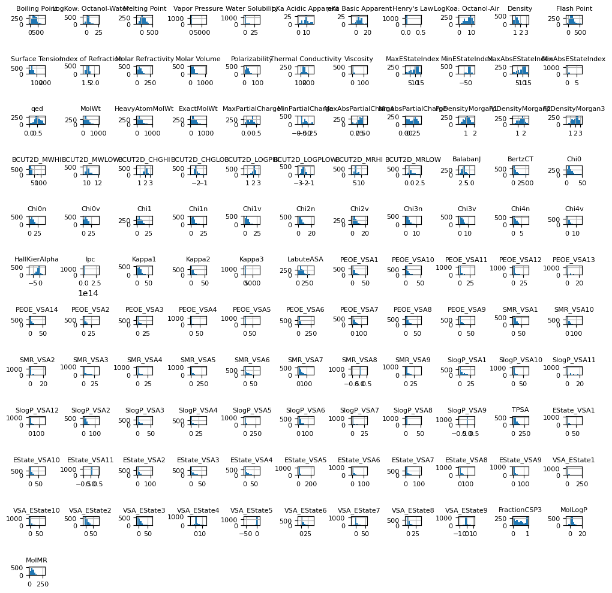

```python
continuous_columns = features.select_dtypes('float').columns
discrete_columns = features.columns.difference(continuous_columns)

_ = plot.histograms_for_columns(
    features[continuous_columns],
    figsize=(10., 10.))
```

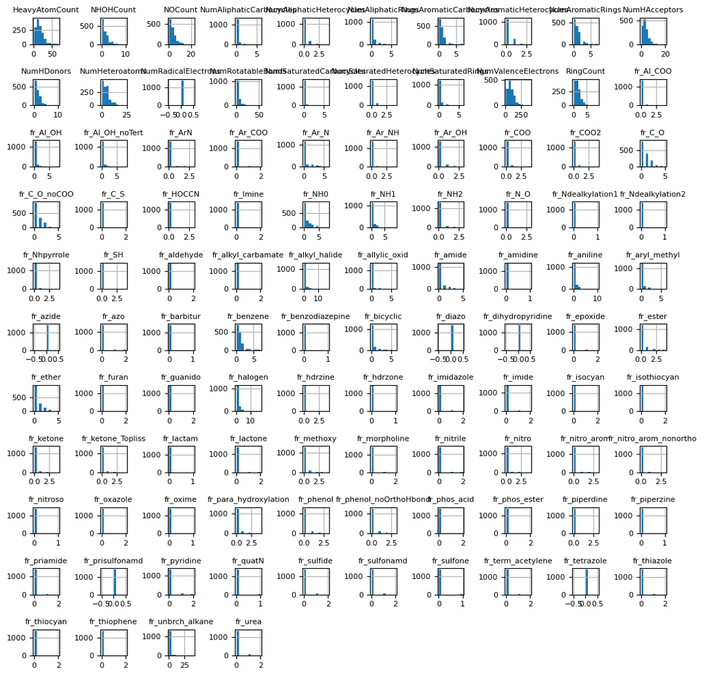

```python
_ = plot.histograms_for_columns(
    features[discrete_columns],
    figsize=(10., 10.))
```

## Preliminary workflow: continuous target (regression task)

Previously, I constructed a random forest with a single train-test split. Following our email exchanges, I tried to improve this model by adapting Prof. Wright's suggestions for incorporating cross validation. I also incorporated preliminary hyperparameter tuning using a *nested* cross-validation strategy and a hyperparameter grid search. I read that using a nested strategy is generally best practice when implementing hyperparameter tuning, in order to avoid overfitting. Let's walk through the implementation.

```python
from sklearn.feature_selection import VarianceThreshold
from sklearn.impute import SimpleImputer
from sklearn.preprocessing import StandardScaler, PowerTransformer, QuantileTransformer
from sklearn.ensemble import RandomForestRegressor
from sklearn.model_selection import KFold, GridSearchCV
from sklearn.pipeline import Pipeline
```

```python
rng = np.random.RandomState(seed=0)

# Define the number of repeats of nested cross validation strategy.
n_repeats = 2  # Prof. Wright recommended 50
# Define the number of folds for the two CV loops.
n_splits_outer = 2
n_splits_inner = 2

imp_median = SimpleImputer(strategy='median')

param_grid = {
    'regr__max_depth': [80, 110],
    'regr__min_samples_leaf': [3, 5],
    'regr__n_estimators': [500, 1000]
}

regr = RandomForestRegressor(
    n_jobs=-1,
    random_state=rng)

pipe = Pipeline(
    steps=[
        ('scalar', scaler),
        ('imputer', imp_median),
        ('regr', regr)])

X, y = features.copy().to_numpy(), target_continuous.copy().to_numpy()
```

```python
%%time

# Initialize container.
cv_for_repeat = {}

# For each repeat, use a different random state for the nested CV splitters.
for i in range(n_repeats):
    print(f'Repeat {i}')

    # Configure the outer cross-validation procedure.
    # Returns a list of randomized indices in which to split.
    cv_outer = KFold(n_splits=n_splits_outer, shuffle=True, random_state=i)

    # Initialize container.
    results_for_fold = []

    # Implement the nested cross validation.
    for j, (train_ix, test_ix) in enumerate(cv_outer.split(X)):
        print(f'  Outer loop {j}...')

        # Split the data.
        X_train, X_test = X[train_ix, :], X[test_ix, :]
        y_train, y_test = y[train_ix], y[test_ix]

        # Configure the inner cross-validation procedure for the grid search.
        cv_inner = KFold(n_splits=n_splits_inner, shuffle=True, random_state=i)

        # Initialize the hyperparameter search grid. By default, the search
        # learns the parameters that maximize the mean score (R2) qcross the
        # inner CV loop.
        search = GridSearchCV(
            estimator=pipe,
            param_grid=param_grid,
            scoring='r2',
            cv=cv_inner,
            refit=True,
            n_jobs=-1)

        # Implement the grid search.
        result = search.fit(X_train, y_train)

        # Find the "best" model fit on the full training set.
        best_model = result.best_estimator_

        # Evaluate the model on the held-out test set.
        yhat = best_model.predict(X_test)

        results_for_fold.append(
            {'best_mean_score': result.best_score_,
            **result.best_params_})

    cv_for_repeat[i] = pd.DataFrame(results_for_fold)

cv_for_repeat = pd.concat(cv_for_repeat)
cv_for_repeat.index.names = ['repeat', 'outer_fold']

cv_for_repeat
```

```
Repeat 0
  Outer loop 0...
  Outer loop 1...
Repeat 1
  Outer loop 0...
  Outer loop 1...
Wall time: 1min 5s
```

| repeat | outer_fold | best_mean_score | regr__max_depth | regr__min_samples_leaf | regr__n_estimators |
| --- | --- | --- | --- | --- | --- |
| 0 | 0 | 0.334155 | 80 | 3 | 500 |
|  | 1 | 0.332746 | 80 | 3 | 1000 |
| 1 | 0 | 0.362630 | 80 | 3 | 500 |
|  | 1 | 0.314698 | 80 | 3 | 500 |

## Potential next steps

### 1. More extensive feature preprocessing

1. Drop constant features
2. Drop features with missing values exceeding threshold % (10 default)
3. Impute missing values with medians
4. Apply log10 and/or other transformations to reduce skewness
5. Center & scale continuous features
6. Remove strong correlations among features (default > 0.9, Pearson)

### 2. Incorporating feature selection into the workflow

### 3. Trying other estimators and shortlisting a few top-performers:

Perhaps using a less computationally intensive workflow.

### 4. More robust hyperparameter tuning

I envision doing a literature review for the top-performing estimators to get a sense of which hyperparameters are most important and across which ranges.

### 5. Building an ensemble of top-performers

### 6. Randomly permuting the target variable to check for any subtle overfitting

## Questions

### Feedback on the workflow?

### Recommendations for feature selection?

### Making the hyperparameter tuning "a little more restrictive"

Concept of "prediction shrinkage"?

### Other estimators that may be worth considering beyond random forest?